# Cyclistic Analysis - User Profiles

## Most Popular Stations Used by Annual Members

Here, we are interested in where the current annual members are using Cyclistic the most. For this section, we will target the 10 most frequented stations for both start and end. By doing so, we realized that both number one stations were “no station” so, we did another search to get only the existing stations.

```r
new_df %>% #first search revealing the "no station" phenomenon
  group_by(member_casual) %>%
  count(start_station_name) %>%
  filter(member_casual == "member") %>%
  arrange(desc(n)) %>%
  head(10)
```

```
## # A tibble: 10 × 3
## # Groups:   member_casual [1]
##    member_casual start_station_name                n
##    <chr>         <chr>                         <int>
##  1 member        no station                   455233
##  2 member        Kingsbury St & Kinzie St      22358
##  3 member        Clark St & Elm St             20931
##  4 member        Clinton St & Washington Blvd  20808
##  5 member        University Ave & 57th St      19845
##  6 member        Wells St & Concord Ln         19610
##  7 member        Ellis Ave & 60th St           19156
##  8 member        Loomis St & Lexington St      18903
##  9 member        Clinton St & Madison St       17315
## 10 member        Wells St & Elm St             17148
```

```r
df %>%
  drop_na() %>%
  group_by(member_casual) %>%
  count(start_station_name) %>%
  filter(member_casual == "member") %>%
  arrange(desc(n)) %>%
  head(10)
```

```
## # A tibble: 10 × 3
## # Groups:   member_casual [1]
##    member_casual start_station_name               n
##    <chr>         <chr>                        <int>
##  1 member        Kingsbury St & Kinzie St     20727
##  2 member        Clinton St & Washington Blvd 19470
##  3 member        Clark St & Elm St            19345
##  4 member        Loomis St & Lexington St     17877
##  5 member        Wells St & Concord Ln        17789
##  6 member        University Ave & 57th St     17677
##  7 member        Ellis Ave & 60th St          17668
##  8 member        Clinton St & Madison St      16169
##  9 member        Canal St & Adams St          15582
## 10 member        Wells St & Elm St            15546
```

```r
df %>%
  drop_na() %>%
  group_by(member_casual) %>%
  count(end_station_name) %>%
  filter(member_casual == "member") %>%
  arrange(desc(n)) %>%
  head(10)
```

```
## # A tibble: 10 × 3
## # Groups:   member_casual [1]
##    member_casual end_station_name                 n
##    <chr>         <chr>                        <int>
##  1 member        Kingsbury St & Kinzie St     21458
##  2 member        Clark St & Elm St            20146
##  3 member        Clinton St & Washington Blvd 20102
##  4 member        Loomis St & Lexington St     18317
##  5 member        University Ave & 57th St     18097
##  6 member        Wells St & Concord Ln        18088
##  7 member        Ellis Ave & 60th St          17373
##  8 member        Clinton St & Madison St      17123
##  9 member        Wells St & Elm St            16384
## 10 member        Canal St & Adams St          15124
```

## Most Popular Stations Used by Casual Members

We then did the same thing for the casual members. Since both number one stations were also “no station”, we will only focus on the existing stations here.

```r
df %>%
  drop_na() %>%
  group_by(member_casual) %>%
  count(start_station_name) %>%
  filter(member_casual == "casual") %>%
  arrange(desc(n)) %>%
  head(10)
```

```
## # A tibble: 10 × 3
## # Groups:   member_casual [1]
##    member_casual start_station_name                     n
##    <chr>         <chr>                              <int>
##  1 casual        Streeter Dr & Grand Ave            39439
##  2 casual        DuSable Lake Shore Dr & Monroe St  23460
##  3 casual        Millennium Park                    18030
##  4 casual        Michigan Ave & Oak St              17822
##  5 casual        DuSable Lake Shore Dr & North Blvd 15490
##  6 casual        Shedd Aquarium                     15395
##  7 casual        Theater on the Lake                12576
##  8 casual        Wells St & Concord Ln              11259
##  9 casual        Dusable Harbor                     10724
## 10 casual        Indiana Ave & Roosevelt Rd          9913
```

```r
df %>%
  drop_na() %>%
  group_by(member_casual) %>%
  count(end_station_name) %>%
  filter(member_casual == "casual") %>%
  arrange(desc(n)) %>%
  head(10)
```

```
## # A tibble: 10 × 3
## # Groups:   member_casual [1]
##    member_casual end_station_name                       n
##    <chr>         <chr>                              <int>
##  1 casual        Streeter Dr & Grand Ave            41763
##  2 casual        DuSable Lake Shore Dr & Monroe St  22068
##  3 casual        Millennium Park                    19704
##  4 casual        Michigan Ave & Oak St              18888
##  5 casual        DuSable Lake Shore Dr & North Blvd 17508
##  6 casual        Shedd Aquarium                     13711
##  7 casual        Theater on the Lake                13641
##  8 casual        Wells St & Concord Ln              10713
##  9 casual        Clark St & Armitage Ave            10002
## 10 casual        Dusable Harbor                      9923
```

## Bikes Taken & Left on the Streets

Surprised by what we found in the previous results, we are now looking at the percentages of bikes that have been taken from the streets and the ones from those that were left on the streets.

### Taken

```r
new_df %>%
  group_by(member_casual) %>%
  count(start_station_name) %>%
  mutate(perc = n/sum(n)) %>%
  select(-n) %>%
  arrange(desc(perc)) %>%
  head(2) #results showed that the most popular place to take a bike was from the street from both casual and annual members
```

```
## # A tibble: 2 × 3
## # Groups:   member_casual [2]
##   member_casual start_station_name  perc
##   <chr>         <chr>              <dbl>
## 1 casual        no station         0.156
## 2 member        no station         0.144
```

### Left

```r
new_df %>%
  group_by(member_casual) %>%
  count(end_station_name) %>%
  mutate(perc = n/sum(n)) %>%
  select(-n) %>%
  arrange(desc(perc)) %>%
  head(2)
```

```
## # A tibble: 2 × 3
## # Groups:   member_casual [2]
##   member_casual end_station_name  perc
##   <chr>         <chr>            <dbl>
## 1 casual        no station       0.183
## 2 member        no station       0.144
```

## Time Spent Using Cyclistic

For this section, we are looking at how long both segments spent using Cyclistic services.

```r
aggregate(ride_length ~ member_casual, data = df, mean)
```

```
##   member_casual   ride_length
## 1        casual 1234.058 secs
## 2        member  713.960 secs
```

## Traffic per Day of the Week

With the information gathered on each segment’s favorite station and their average time spent on Cyclistic’s bicycles, our last step consists at looking at their weekly habits to find out which day(s) of the week are most popular.

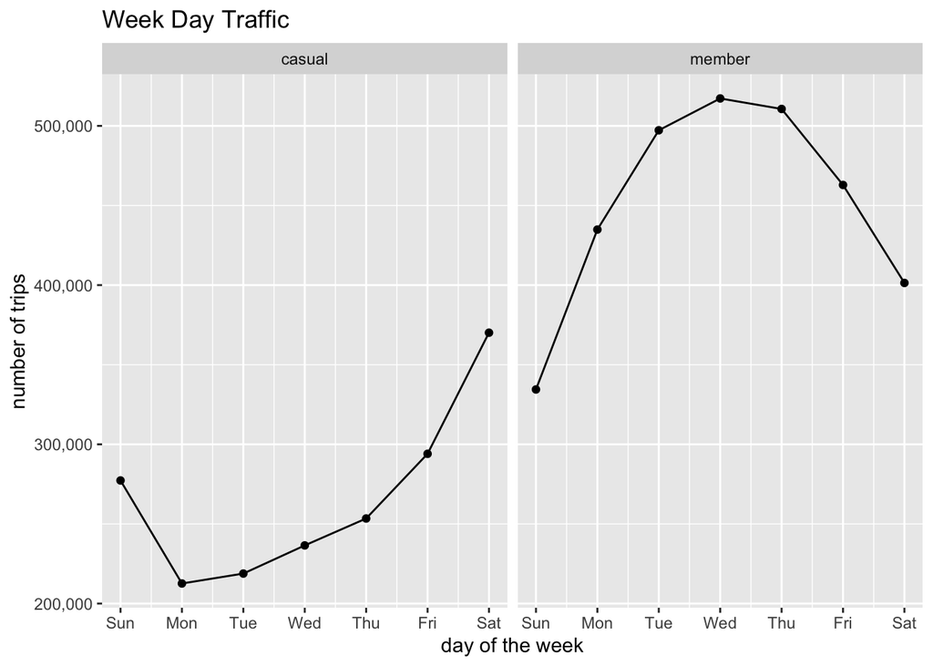

```r
day_of_week_df <- df %>%
  group_by(member_casual) %>%
  count(day_of_week)

ggplot(data = day_of_week_df) +
  geom_point(mapping = aes(x = day_of_week, y = n)) +
  geom_line(mapping = aes(x = day_of_week, y = n)) +
  facet_wrap(~member_casual) +
  labs(title = "Week Day Traffic", y = "number of trips", x = "day of the week") +
  scale_y_continuous(labels = comma) +
  scale_x_continuous(breaks = c(1:7),
    labels = c("Sun","Mon","Tue","Wed","Thu","Fri","Sat"))
```

# Conclusion

With these observations, we can conclude that most of Cyclistic casual members use the bike-sharing service for leisure while the annual members mainly use it for work.

Considering this, the best way to convert the casual riders into annual members is to tap into the benefits of using Cyclistic for leisure activities in Chicago. Using this analysis as a tool, the marketing team could look into the main attractions located next to the top 10 stations used by the casual riders and work on special deals (ex: 10% off the bill) exclusive for Cyclistic annual members. This analysis clearly shows the traffic around these landmarks as an argument to negotiate with local businesses.

From their side, the participating attractions and businesses will increase their number of sales and customers as well as receiving free publicity through Cyclistic’s various platforms.

From Cyclistic’s side, they increase their number of annual members and therefore, profit. They also strengthen their relationship with the city which could be useful for future projects. It is a win-win situation that is worth exploring.